# R Notebook

NFL Principal Component Analysis

# Singular Value Decomposition

## Dimensionality Reduction

`nflverse`

Data:

- rec: total receptions to filter out players with small sample size
- air_yards: distance the ball traveled in the air before reaching them
- yards_per_target: total yards / targets
- yards_after_catch: yards after the ball was caught
- td_rate: touchdowns per target
- outside_rec: binary variable if the receiver caught the ball outside the hashes
- dist_from_sticks: where they were targeted relative to distance needed to continue drive

```r
pbp_data <- purrr::map_df(2015:2020, function(x) {
  read_rds(
    glue("~/Desktop/nfl_coding/data/pbp/play_by_play_{x}.rds")
    )})
```

```
Error in glue("~/Desktop/nfl_coding/data/pbp/play_by_play_{x}.rds") :
  could not find function "glue"
```

```r
pbp_roster <- pbp_data %>%
  left_join(
    rosters %>%
      select(position, season, gsis_id),
        by = c('fantasy_id' = 'gsis_id', 'season'))


wr <- pbp_roster %>%
  filter(position == 'WR')
```

```r
wr_stats_full <- wr %>%
  mutate(
    outside_pass = ifelse(pass_location != 'middle', 1, 0),
    pass_air_yards = ifelse(is.na(air_yards), 0, air_yards),
    pass_air_yards = ifelse(ydstogo <= 10, pass_air_yards, NA)
    ) %>%
  group_by(receiver_id) %>%
  summarise(
    rec = sum(complete_pass),
    air_yards = mean(pass_air_yards, na.rm = TRUE),
    yards_per_target = mean(yards_gained, na.rm = TRUE),
    yards_after_catch = mean(yards_after_catch, na.rm = TRUE),
    td_rate = mean(pass_touchdown),
    outside_rec = mean(outside_pass, na.rm = TRUE),
    dist_from_sticks = mean(pass_air_yards - ydstogo, na.rm = TRUE)
  ) %>%
  filter(rec > 50) %>%
  left_join(
    pbp_data %>%
      count(receiver_id, receiver, posteam) %>%
      group_by(receiver_id) %>%
      arrange(-n) %>%
      mutate(rn = row_number()) %>%
      filter(rn == 1) %>%
      select(-n, -rn)) %>%
  relocate(receiver, .before = rec)
wr_stats <- wr_stats_full %>%
  select(-starts_with('rec'), -posteam) %>%
  scale()
```

```r
wr_stats %>%
  as_tibble()
```

| air_yards | yards_per_target | yards_after_catch | td_rate | outside_rec | dist_from_sticks |
| --- | --- | --- | --- | --- | --- |
| -1.884763598 | -1.021063616 | -0.473623753 | 0.450989073 | -0.58286317 | -1.69379706 |
| -1.209904204 | -0.483152109 | -0.475582968 | -0.243024804 | -0.89447458 | -1.22998072 |
| 0.401841652 | -0.497302023 | -0.900232170 | 0.254224098 | 1.26199352 | 0.44709781 |
| 0.830436438 | 0.321442728 | -0.965214699 | 0.605056508 | 0.98017059 | 0.97849457 |
| 1.405899126 | 0.757836016 | -0.152160455 | 0.519579665 | 1.48488965 | 1.20942087 |
| -2.247410875 | -0.910022138 | 0.793911004 | -0.715521505 | 1.45770474 | -2.26741319 |
| 2.198507198 | 1.527040747 | 0.094899531 | 0.109839753 | 1.43283925 | 2.24781280 |
| 0.033588601 | -1.447832959 | -0.650367372 | -1.397012451 | 1.20437158 | 0.15072116 |
| -0.451452637 | 0.027939612 | -0.647352877 | -0.926921936 | -0.49590677 | -0.42573388 |
| 0.799156609 | 0.052854336 | 0.216810722 | -0.651207640 | -1.26269104 | 0.81423883 |

[output cut: 111 more lines]

## PCA from scratch

Singular value decomposition is a matrix factorization method that generalizes eigendecomposition of a matrix.

$U$

$\sum$ is the diagonal matrix containing the eigenvalues

$V$ contains the eigen vectors

```r
U <- svd(wr_stats)$u
D <- svd(wr_stats)$d
V <- svd(wr_stats)$v

DS <- diag(1/svd(wr_stats)$d[1:2])
US <- as.matrix(U[,1:2])
VS <- as.matrix(V[,1:2])


final <- VS %*% DS %*% t(US)

pca_data <- final[1:2, ] %>% MASS::ginv()

# Principal components explained variance
sum(D[[1]], D[[2]])/sum(D)
```

```
[1] 0.5352784
```

Using `SVD` to get the principal components, we can use the largest 2 to explain the ~54% of the variance. This allows for a 2 dimensional scatter plot to analyze players. Both Deebo Samuel (SF) and AJ Brown (TEN) stick out from the chart. Samuel gets used almost as a running back in his system, and AJ Brown is a deep vertical threat that also excels with yards after the catch.

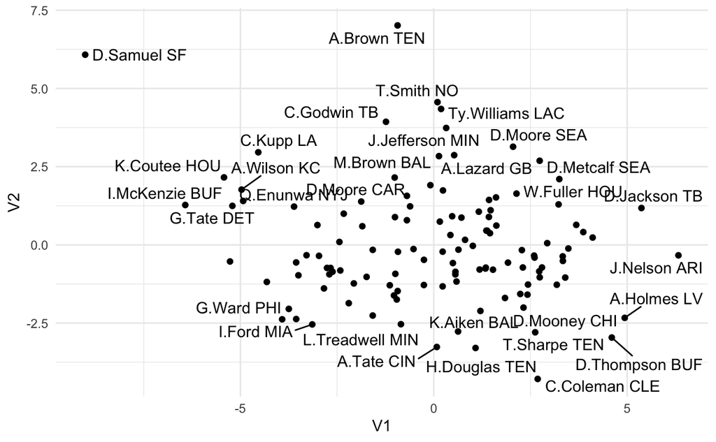

```r
pca_data %>%
  as_tibble() %>%
  bind_cols(
    wr_stats_full %>%
      select(starts_with("rec"), posteam)) %>%
  ggplot(aes(V1, V2)) +
  geom_point() +
  ggrepel::geom_text_repel(
    aes(label = paste(receiver, posteam)),
    max.overlaps = 10) +
  theme_minimal()
```